# Welcome to the Personal Project - OptiMarket: Uncovering the Ultimate Marketing Approach

Hello! I'm Ayumu Justin Ueda, a Data Science student at UC Berkeley. You can find my profile on (https://www.linkedin.com/in/ayumu-ueda-ab1879224/).

In this project, as a data scientist at a car insurance company, I've been provided with last year's data documenting the outcomes of marketing campaigns involving various types of strategies (a combination of insurance renewal plans - Offer1 and Offer2, and different sales channels - Agent, Branch, Call Center, Email).

## Objective:

My objective is to enhance the KPI, specifically the acceptance rate of offers, in the upcoming marketing phase by identifying the most effective combinations of customer segments and marketing strategies (a combination of offer type and sales channel).

## Project Overview:

### 1. Customer segmentation for pinpointing optimal marketing strategies in each category:

**Skills Applied:**

- Parametric Statistical Inference(Test of Homogeneity, Chi Square Test)
- K-means Clustering
- Principal Component Analysis (PCA)

**Conclusion for this section:**

|  | cluster | best marketing strategy |
| --- | --- | --- |
| 0 | 0 | Offer2_Agent |
| 1 | 1 | Offer1_Email |
| 2 | 2 | Offer2_Branch |
| 3 | 3 | Offer2_Agent |
| 4 | 4 | Offer2_Call Center |
| 5 | 5 | Offer2_Agent |
| 6 | 6 | Offer2_Email |
| 7 | 7 | Offer2_Email |
| 8 | 8 | Offer2_Call Center |
| 9 | 9 | Offer2_Agent |

The best combination of marketing strategies is as outlined above.

For future marketing initiatives, we can utilize customer information such as gender, education, etc., categorizing them into one of the ten groups mentioned. This approach allows us to employ the most effective marketing strategy for each group, ultimately increasing the number of car insurance renewals and enhancing the profitability of our insurance department.

### 2. Optimizing Email Sales through A/B Testing:

**Skills Applied:**

- Parametric Statistical Inference(Anova one sided test)
- Non-Parametric Statistical Inference(Kruskal-Wallis test)
- A/B test (Bootstrap)

**Conclusion for this section:**

After conducting A/B testing on the marketing campaign, it's evident that Promotion 1 is the most effective in increasing sales.

I have decided to implement Promotion 1 for the email marketing campaign.

### **0. Importing libraries**

```python
import pandas as pd
import matplotlib.pyplot as plt
import sklearn
import seaborn as sns
import numpy as np
import statsmodels.api as sm
import scipy.stats as stats
from sklearn.decomposition import PCA
from sklearn.metrics import silhouette_score
from sklearn.cluster import KMeans
from sklearn.preprocessing import StandardScaler
from scipy.stats import chi2_contingency
from sklearn.model_selection import train_test_split
from sklearn.preprocessing import MinMaxScaler
import warnings
warnings.filterwarnings("ignore")
```

### **1. Customer segmentation for pinpointing optimal marketing strategies in each category:**

#### **Data Preprocessing**

```python
df = pd.read_csv("/content/drive/MyDrive/business data project/dataset/WA_Fn-UseC_-Marketing-Customer-Value-Analysis.csv")
```

```python
df['Response'] = df['Response'].apply(lambda x:1 if x=='Yes' else 0)
df['Sales Channel'] = df['Sales Channel'].replace('Web', 'Email')
df = df[df['Renew Offer Type'] != 'Offer4']
df = df[df['Renew Offer Type'] != 'Offer3']
df['Marketing Strategy'] = df['Renew Offer Type'] + "_" + df['Sales Channel']
df = df.drop(['Customer','Effective To Date','Renew Offer Type','Sales Channel'], axis=1)
df = df.reset_index(drop=True)
df.head()
```

|  | State | Customer Lifetime Value | Response | Coverage | Education | EmploymentStatus | Gender | Income | Location Code | Marital Status | ... | Months Since Last Claim | Months Since Policy Inception | Number of Open Complaints | Number of Policies | Policy Type | Policy | Total Claim Amount | Vehicle Class | Vehicle Size | Marketing Strategy |
| --- | --- | --- | --- | --- | --- | --- | --- | --- | --- | --- | --- | --- | --- | --- | --- | --- | --- | --- | --- | --- | --- |
| 0 | Washington | 2763.519279 | 0 | Basic | Bachelor | Employed | F | 56274 | Suburban | Married | ... | 32 | 5 | 0 | 1 | Corporate Auto | Corporate L3 | 384.811147 | Two-Door Car | Medsize | Offer1_Agent |
| 1 | Nevada | 12887.431650 | 0 | Premium | Bachelor | Employed | F | 48767 | Suburban | Married | ... | 18 | 38 | 0 | 2 | Personal Auto | Personal L3 | 566.472247 | Two-Door Car | Medsize | Offer1_Agent |
| 2 | California | 7645.861827 | 0 | Basic | Bachelor | Unemployed | M | 0 | Suburban | Married | ... | 18 | 65 | 0 | 7 | Corporate Auto | Corporate L2 | 529.881344 | SUV | Medsize | Offer1_Call Center |
| 3 | Washington | 2813.692575 | 0 | Basic | Bachelor | Employed | M | 43836 | Rural | Single | ... | 12 | 44 | 0 | 1 | Personal Auto | Personal L1 | 138.130879 | Four-Door Car | Medsize | Offer1_Agent |
| 4 | Oregon | 8256.297800 | 1 | Basic | Bachelor | Employed | F | 62902 | Rural | Married | ... | 14 | 94 | 0 | 2 | Personal Auto | Personal L3 | 159.383042 | Two-Door Car | Medsize | Offer2_Email |

5 rows × 21 columns

#### **the acceptance rate across the dataset**

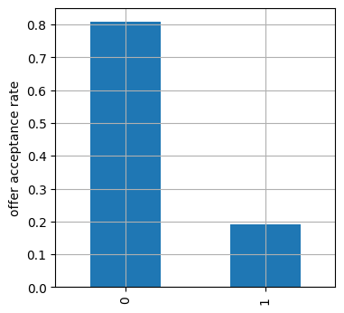

```python
(df['Response'].value_counts() / len(df)).plot.bar(figsize=(4,4), grid=True)
plt.ylabel("offer acceptance rate")
```

acceptance rate of offers was around 20% in previous campaign

#### **the acceptance rate by marketing strategies**

Population distribution of the acceptance rate by marketing strategies

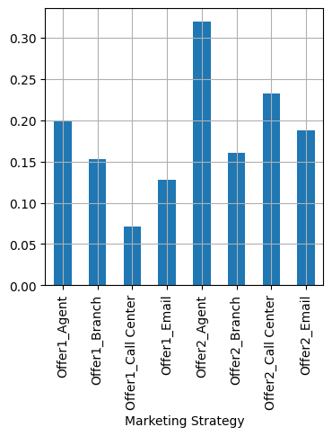

```python
df.groupby('Marketing Strategy').mean()['Response'].plot.bar(figsize=(4,4), grid=True)
```

#### **Test of homogenity (chi-square test)**

If distribution of acceptance rate by various type of marketing strategies changes depending on another factor like education, another factor like educational background influences on their preference of the our marketing strategies. For instance, people with a bachelors degree tend to prefer the offer2 through E-mail.

#### **Let's test if customer's education affect the distribution of acceptance rate by marketing strategies by test of homogenity (chi-square test) (https://shorturl.at/mXYZ8)**

```python
df['Education'].value_counts()
```

```
Bachelor                2089
College                 1953
High School or Below    1878
Master                   519
Doctor                   239
Name: Education, dtype: int64
```

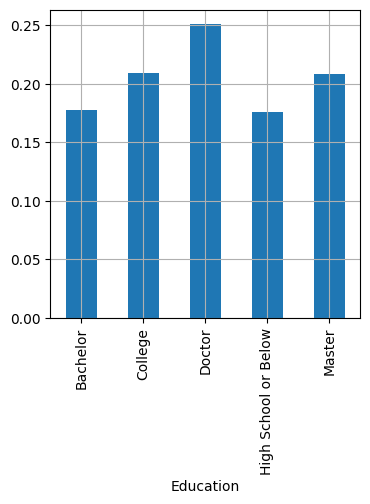

```python
df.groupby(['Education']).mean()["Response"].plot(kind='bar', figsize=(4,4), grid=True)
```

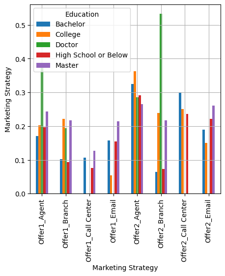

```python
df.groupby(['Marketing Strategy', 'Education']).mean()["Response"].unstack('Education').plot(kind='bar', figsize=(5,5), grid=True)
plt.ylabel("Marketing Strategy")
```

Null and Alternative hypothesis for this test

- Null hypothesis: there is not significant difference in the distribution of acceptance rate by marketing strategy among customers with five different educational background
- Alternative hypothesis : there is significant difference in the distribution of acceptance rate by marketing strategy among customers with five different educational background

```python
observed_data = df.groupby(['Marketing Strategy', 'Education']).sum()["Response"].unstack('Education')
observed_data
```

| Education Marketing Strategy | Bachelor | College | Doctor | High School or Below | Master |
| --- | --- | --- | --- | --- | --- |
| Offer1_Agent | 96 | 102 | 18 | 90 | 30 |
| Offer1_Branch | 36 | 84 | 6 | 24 | 18 |
| Offer1_Call Center | 24 | 0 | 0 | 12 | 6 |
| Offer1_Email | 18 | 6 | 0 | 18 | 6 |
| Offer2_Agent | 96 | 96 | 12 | 90 | 18 |
| Offer2_Branch | 12 | 54 | 24 | 18 | 18 |
| Offer2_Call Center | 60 | 42 | 0 | 48 | 0 |
| Offer2_Email | 30 | 24 | 0 | 30 | 12 |

```python
chi2_stat, p_value, dof, expected = chi2_contingency(observed_data)

print(f"Chi2 Stat: {chi2_stat}")
print(f"P-value: {p_value}")
print(f'Degrees of Freedom: {dof}')
print(f'Expected Frequencies: \n{expected}')
```

```
Chi2 Stat: 203.30609150716455
P-value: 1.6205214050962778e-28
Degrees of Freedom: 28
Expected Frequencies:
[[ 97.8028169  107.26760563  15.77464789  86.76056338  28.3943662 ]
 [ 48.90140845  53.63380282   7.88732394  43.38028169  14.1971831 ]
 [ 12.22535211  13.4084507    1.97183099  10.84507042   3.54929577]
 [ 13.97183099  15.32394366   2.25352113  12.3943662    4.05633803]
 [ 90.81690141  99.6056338   14.64788732  80.56338028  26.36619718]
 [ 36.67605634  40.22535211   5.91549296  32.53521127  10.64788732]
 [ 43.66197183  47.88732394   7.04225352  38.73239437  12.67605634]
 [ 27.94366197  30.64788732   4.50704225  24.78873239   8.11267606]]
```

p-value is small enough to reject null hypothesis and accept alternative hypothesis

**Conclusion**

- the distribution of marketing strategy changes depending on customer's educational backgroud, so we might be able to increase the marketing engagement by changing markeiting strategy depending on the customer's education.

#### **Conduct the same test to all categorical variables and find the variables which affect the distribution of acceptance rate among marketing strategies (the offer type and Sales Channel).**

#### **change the continous variables to categorical variables by binning the data using pandas qcut which discretize variable into equal-sized buckets based on rank or based on sample quantiles.**

For the income column, implement a three-class binning approach: lower class, middle class, and upper class.

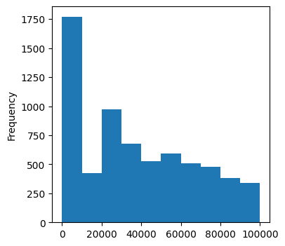

```python
plt.figure(figsize=(4,4))
df['Income'].plot.hist(bins=10)
```

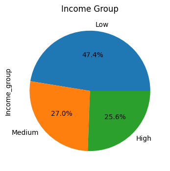

```python
bins = [-float('inf'), 30000, 60000, float('inf')]
labels = ['Low', 'Medium', 'High']
df['Income_group'] = pd.cut(df['Income'], bins=bins, labels=labels, right=False)
plt.figure(figsize=(4,4))
df['Income_group'].value_counts().plot.pie(autopct='%1.1f%%')
plt.title("Income Group")
```

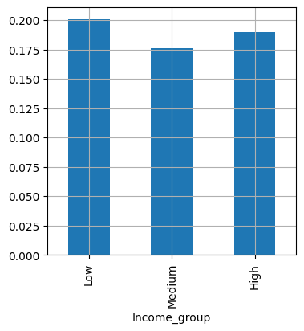

```python
df = df.drop(['Income'], axis=1)
df.groupby(['Income_group']).mean()["Response"].plot(kind='bar', figsize=(4,4), grid=True)
```

For the remaining columns, apply the qcut method to perform binning.

```python
for col in df.columns:
  try:
    if df[col].dtype != 'object' and col != 'Response' and df[col].dtype != 'category':
      df[col] = pd.qcut(df[col], 3, labels=False)
  except:
    print(f"{col} is discrete number ")
```

```
Number of Open Complaints is discrete number
Number of Policies is discrete number
```

```python
df.head()
```

|  | State | Customer Lifetime Value | Response | Coverage | Education | EmploymentStatus | Gender | Location Code | Marital Status | Monthly Premium Auto | ... | Months Since Policy Inception | Number of Open Complaints | Number of Policies | Policy Type | Policy | Total Claim Amount | Vehicle Class | Vehicle Size | Marketing Strategy | Income_group |
| --- | --- | --- | --- | --- | --- | --- | --- | --- | --- | --- | --- | --- | --- | --- | --- | --- | --- | --- | --- | --- | --- |
| 0 | Washington | 0 | 0 | Basic | Bachelor | Employed | F | Suburban | Married | 0 | ... | 0 | 0 | 1 | Corporate Auto | Corporate L3 | 1 | Two-Door Car | Medsize | Offer1_Agent | Medium |
| 1 | Nevada | 2 | 0 | Premium | Bachelor | Employed | F | Suburban | Married | 2 | ... | 1 | 0 | 2 | Personal Auto | Personal L3 | 2 | Two-Door Car | Medsize | Offer1_Agent | Medium |
| 2 | California | 1 | 0 | Basic | Bachelor | Unemployed | M | Suburban | Married | 2 | ... | 2 | 0 | 7 | Corporate Auto | Corporate L2 | 2 | SUV | Medsize | Offer1_Call Center | Low |
| 3 | Washington | 0 | 0 | Basic | Bachelor | Employed | M | Rural | Single | 1 | ... | 1 | 0 | 1 | Personal Auto | Personal L1 | 0 | Four-Door Car | Medsize | Offer1_Agent | Medium |
| 4 | Oregon | 2 | 1 | Basic | Bachelor | Employed | F | Rural | Married | 0 | ... | 2 | 0 | 2 | Personal Auto | Personal L3 | 0 | Two-Door Car | Medsize | Offer2_Email | High |

5 rows × 21 columns

#### **Conduct chi-square test**

```python
significant_col = []
for col in df.columns:
  if col == "Response" or col == "Marketing Strategy":
    continue
  else:
    observed_data = df.groupby(["Marketing Strategy", col]).sum()["Response"].unstack(col)
    observed_data
    chi2_stat, p_value, dof, expected = chi2_contingency(observed_data)
    if p_value < 0.05:
      significant_col.append(col)
      print(f"{col} is significant")
    else:
      print(f"{col} is not significant")
```

```
State is not significant
Customer Lifetime Value is significant
Coverage is significant
Education is significant
EmploymentStatus is significant
Gender is significant
Location Code is significant
Marital Status is significant
Monthly Premium Auto is significant
Months Since Last Claim is significant
Months Since Policy Inception is significant
Number of Open Complaints is not significant
Number of Policies is significant
Policy Type is not significant
Policy is not significant
Total Claim Amount is significant
Vehicle Class is significant
Vehicle Size is significant
Income_group is significant
```

```python
significant_col
```

```
['Customer Lifetime Value',
 'Coverage',
 'Education',
 'EmploymentStatus',
 'Gender',
 'Location Code',
 'Marital Status',
 'Monthly Premium Auto',
 'Months Since Last Claim',
 'Months Since Policy Inception',
 'Number of Policies',
 'Total Claim Amount',
 'Vehicle Class',
 'Vehicle Size',
 'Income_group']
```

**Conclusion**

the above columns has significant effect to decide the most effective marketing strategy, let's use these columns for segmentation

#### **Customer Segmentation**

Now that we've identified which columns might be useful for segmentation, let's discover the favorite marketing strategies for each segment.

#### **encoding categorical variables to numeric vectors**

```python
df_copy = df.copy(deep=True)
df_copy = df_copy[significant_col]
df_copy = pd.get_dummies(df_copy, columns = df_copy.columns)
df_copy.head()
```

|  | Customer Lifetime Value_0 | Customer Lifetime Value_1 | Customer Lifetime Value_2 | Coverage_Basic | Coverage_Extended | Coverage_Premium | Education_Bachelor | Education_College | Education_Doctor | Education_High School or Below | ... | Vehicle Class_Luxury SUV | Vehicle Class_SUV | Vehicle Class_Sports Car | Vehicle Class_Two-Door Car | Vehicle Size_Large | Vehicle Size_Medsize | Vehicle Size_Small | Income_group_Low | Income_group_Medium | Income_group_High |
| --- | --- | --- | --- | --- | --- | --- | --- | --- | --- | --- | --- | --- | --- | --- | --- | --- | --- | --- | --- | --- | --- |
| 0 | 1 | 0 | 0 | 1 | 0 | 0 | 1 | 0 | 0 | 0 | ... | 0 | 0 | 0 | 1 | 0 | 1 | 0 | 0 | 1 | 0 |
| 1 | 0 | 0 | 1 | 0 | 0 | 1 | 1 | 0 | 0 | 0 | ... | 0 | 0 | 0 | 1 | 0 | 1 | 0 | 0 | 1 | 0 |
| 2 | 0 | 1 | 0 | 1 | 0 | 0 | 1 | 0 | 0 | 0 | ... | 0 | 1 | 0 | 0 | 0 | 1 | 0 | 1 | 0 | 0 |
| 3 | 1 | 0 | 0 | 1 | 0 | 0 | 1 | 0 | 0 | 0 | ... | 0 | 0 | 0 | 0 | 0 | 1 | 0 | 0 | 1 | 0 |
| 4 | 0 | 0 | 1 | 1 | 0 | 0 | 1 | 0 | 0 | 0 | ... | 0 | 0 | 0 | 1 | 0 | 1 | 0 | 0 | 0 | 1 |

5 rows × 57 columns

```python
scaler = StandardScaler()
df_copy = scaler.fit_transform(df_copy)
df_copy
```

```
array([[ 1.41421356, -0.70710678, -0.70710678, ..., -0.9497485 ,
         1.64433177, -0.58622689],
       [-0.70710678, -0.70710678,  1.41421356, ..., -0.9497485 ,
         1.64433177, -0.58622689],
       [-0.70710678,  1.41421356, -0.70710678, ...,  1.05291032,
        -0.60814978, -0.58622689],
       ...,
       [-0.70710678, -0.70710678,  1.41421356, ..., -0.9497485 ,
        -0.60814978,  1.70582416],
       [ 1.41421356, -0.70710678, -0.70710678, ...,  1.05291032,
        -0.60814978, -0.58622689],
       [-0.70710678, -0.70710678,  1.41421356, ...,  1.05291032,
        -0.60814978, -0.58622689]])
```

```python
# sil = []
# kmax = 20
# x = df_copy
# for k in range(2, kmax+1):
#   kmeans = KMeans(n_clusters = k, random_state=0).fit(x)
#   labels = kmeans.labels_
#   sil.append(silhouette_score(x, labels, metric = 'euclidean'))
```

#### **With k-means algorithm, assign cluster number (segment) to each customer**

```python
kmeans = KMeans(n_clusters=10, random_state=0).fit(df_copy)
df['cluster'] = kmeans.labels_.tolist()
df['cluster'].value_counts()
```

```
3    1151
6     995
4     920
2     870
8     825
9     676
5     492
1     310
7     303
0     136
Name: cluster, dtype: int64
```

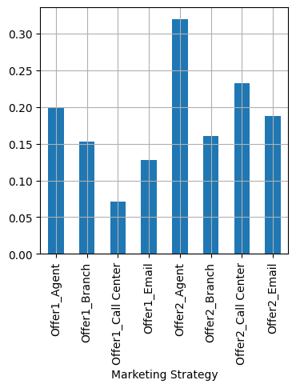

```python
df.groupby(['Marketing Strategy']).mean()['Response'].plot(kind='bar', figsize=(4,4), grid=True)
```

distribution of clusters looks like this

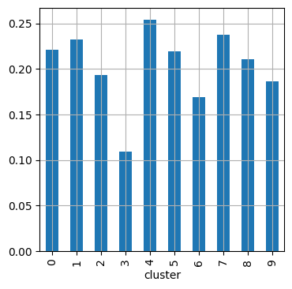

```python
df.groupby(['cluster']).mean()['Response'].plot(kind='bar', figsize=(4,4), grid=True)
```

#### **find the each segment's favorite marketing strategy**

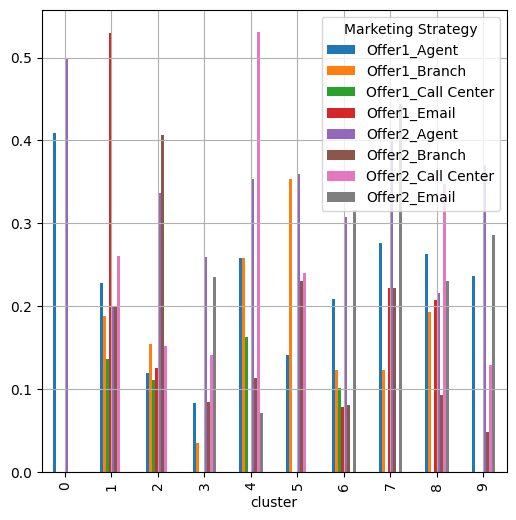

```python
df.groupby(['cluster', 'Marketing Strategy']).mean()['Response'].unstack().plot(kind='bar', figsize=(6,6), grid=True)
```

```python
engagement_rate_matrix = df.groupby(['cluster', 'Marketing Strategy']).mean()['Response'].unstack()
max_cols = np.argmax(engagement_rate_matrix.to_numpy(), axis=1)
strategy_types = engagement_rate_matrix.columns.to_list()
best_strategies = [strategy_types[index] for index in max_cols]
combination_df = pd.DataFrame({"cluster" : engagement_rate_matrix.index.to_list(), "best marketing strategy" : best_strategies})
combination_df
```

|  | cluster | best marketing strategy |
| --- | --- | --- |
| 0 | 0 | Offer2_Agent |
| 1 | 1 | Offer1_Email |
| 2 | 2 | Offer2_Branch |
| 3 | 3 | Offer2_Agent |
| 4 | 4 | Offer2_Call Center |
| 5 | 5 | Offer2_Agent |
| 6 | 6 | Offer2_Email |
| 7 | 7 | Offer2_Email |
| 8 | 8 | Offer2_Call Center |
| 9 | 9 | Offer2_Agent |

#### **Using Principal Component Analysis, compress the columns into two and create a visualization.**

```python
pca = PCA(n_components=2)
viz_k_means = pd.DataFrame(pca.fit_transform(df_copy))
viz_k_means['cluster'] = kmeans.labels_.tolist()
viz_k_means.head()
```

|  | 0 | 1 | cluster |
| --- | --- | --- | --- |
| 0 | -1.487082 | -1.672353 | 9 |
| 1 | 0.634290 | 3.593154 | 2 |
| 2 | 2.650078 | 0.700135 | 6 |
| 3 | -2.357965 | -0.979044 | 9 |
| 4 | -3.367888 | 1.034961 | 3 |

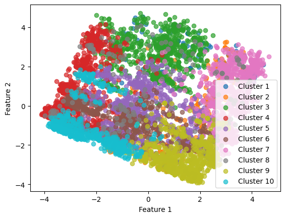

```python
fig = plt.figure()
ax = fig.add_subplot(111)
for i in range(10):
    cluster_points = viz_k_means[viz_k_means['cluster'] == i]
    ax.scatter(cluster_points[0], cluster_points[1], label=f'Cluster {i + 1}', cmap='viridis', alpha=0.7)

ax.set_xlabel('Feature 1')
ax.set_ylabel('Feature 2')

ax.legend()
plt.show()
```

#### **Results from the above segmentation**

The best combination of marketing strategies is as outlined above. For future marketing initiatives, we can utilize customer information such as gender, education, etc., categorizing them into one of the ten groups mentioned. This approach allows us to employ the most effective marketing strategy for each group, ultimately increasing the number of car insurance renewals and enhancing the profitability of our insurance department.

### 2. **Email Marketing Strategy**

We are currently evaluating three options for our upcoming insurance renewal promotion attached to an email. The goal is to determine the most suitable choice to increase sales. Promotion1, 2, 3 include a 5% discount, a 50 dollars discount, and a 50 dollars Apple gift card. I have been provided with data from a small campaign where three types of email sentences with promotions were tested for research purposes.

#### **visualize the other factors which affect testing result than promotion types**

```python
df = pd.read_csv("/content/drive/MyDrive/business data project/dataset/WA_Marketing-Campaign.csv")
```

```python
df.head()
```

|  | MarketID | MarketSize | LocationID | AgeOfStore | Promotion | week | SalesInThousands |
| --- | --- | --- | --- | --- | --- | --- | --- |
| 0 | 1 | Medium | 1 | 4 | 3 | 1 | 33.73 |
| 1 | 1 | Medium | 1 | 4 | 3 | 2 | 35.67 |
| 2 | 1 | Medium | 1 | 4 | 3 | 3 | 29.03 |
| 3 | 1 | Medium | 1 | 4 | 3 | 4 | 39.25 |
| 4 | 1 | Medium | 2 | 5 | 2 | 1 | 27.81 |

```python
promodf = df.groupby('Promotion').sum()
promodf = promodf.reset_index()
promodf.head()
```

|  | Promotion | MarketID | LocationID | AgeOfStore | week | SalesInThousands |
| --- | --- | --- | --- | --- | --- | --- |
| 0 | 1 | 996 | 84016 | 1424 | 430 | 9993.03 |
| 1 | 2 | 1108 | 93520 | 1500 | 470 | 8897.93 |
| 2 | 3 | 1028 | 85316 | 1736 | 470 | 10408.52 |

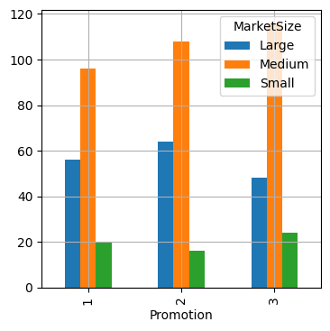

```python
df.groupby(['Promotion', 'MarketSize']).count()['week'].unstack('MarketSize').plot(kind='bar', figsize=(4,4), grid=True)
```

```python
df.groupby("Promotion").describe()['AgeOfStore']
```

| Promotion | count | mean | std | min | 25% | 50% | 75% | max |
| --- | --- | --- | --- | --- | --- | --- | --- | --- |
| 1 | 172.0 | 8.279070 | 6.636160 | 1.0 | 3.0 | 6.0 | 12.0 | 27.0 |
| 2 | 188.0 | 7.978723 | 6.597648 | 1.0 | 3.0 | 7.0 | 10.0 | 28.0 |
| 3 | 188.0 | 9.234043 | 6.651646 | 1.0 | 5.0 | 8.0 | 12.0 | 24.0 |

Given the similar data composition for each promotion, conducting A/B testing becomes crucial for deriving meaningful insights and identifying the most effective promotion method

#### **conduct ANOVA test (parametric)**

Before proceeding with A/B testing, I aim to confirm that each promotion yields distinct outcomes. To achieve this, I've opted for a one-sided ANOVA test.

#### Ensuring that the data adheres to a normal distribution is crucial to meet the essential assumption for ANOVA (Analysis of Variance).

```python
promotion1 = df[df['Promotion'] == 1]
promotion2 = df[df['Promotion'] == 2]
promotion3 = df[df['Promotion'] == 3]

plt.figure(figsize=(4,4))
plt.hist(promotion1['SalesInThousands'])
```

[output not shown]

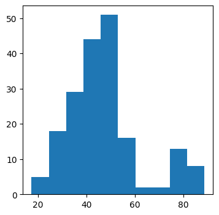

```python
plt.figure(figsize=(4,4))
plt.hist(promotion2['SalesInThousands'])
```

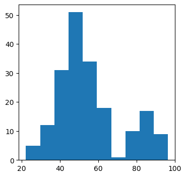

```python
plt.figure(figsize=(4,4))
plt.hist(promotion3['SalesInThousands'])
```

the above visualization tell us that data somehow follow the lightly skewed normal distribution, so I conduct Anova one sided test

```python
from scipy.stats import f_oneway
f_oneway(promotion1['SalesInThousands'], promotion2['SalesInThousands'], promotion3['SalesInThousands'])
```

```
F_onewayResult(statistic=21.953485793080677, pvalue=6.765849261408714e-10)
```

#### **Conduct Kruskal-Wallis test (non-parametric)**

However, it's challenging to determine if provided histogram is normally distributed by our eye. Thus, I have opted for a non-parametric test, specifically the Kruskal-Wallis test.

```python
stats.kruskal(promotion1['SalesInThousands'], promotion2['SalesInThousands'], promotion3['SalesInThousands'])
```

```
KruskalResult(statistic=53.29475169322799, pvalue=2.6741866266697816e-12)
```

#### **Conduct A/B testing**

The above test indicates a significant difference among these methods. To determine the preferable method, I will conduct an A/B test and analyze the results

```python
df.groupby("Promotion").describe()['SalesInThousands']
```

| Promotion | count | mean | std | min | 25% | 50% | 75% | max |
| --- | --- | --- | --- | --- | --- | --- | --- | --- |
| 1 | 172.0 | 58.099012 | 16.553782 | 30.81 | 46.3525 | 55.385 | 63.6175 | 99.65 |
| 2 | 188.0 | 47.329415 | 15.108955 | 17.34 | 38.1700 | 45.385 | 51.7450 | 88.64 |
| 3 | 188.0 | 55.364468 | 16.766231 | 22.18 | 44.1975 | 51.165 | 61.7325 | 96.48 |

- Null Hypothesis : There is no significant difference in the mean sales between Promotion 1 and Promotion 3.
- Alternative Hypothesis : Promotion 1 generates higher sales than Promotion 3.

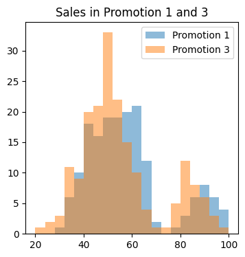

```python
plt.figure(figsize=(4,4))
plt.hist(promotion1['SalesInThousands'], bins=20, alpha=0.5, range=(20,100))
plt.hist(promotion3['SalesInThousands'], bins=20, alpha=0.5, range=(20,100))
plt.legend(labels=['Promotion 1', 'Promotion 3'])
plt.title('Sales in Promotion 1 and 3')
```

```python
test_statistic = np.mean(promotion1['SalesInThousands']) - np.mean(promotion3['SalesInThousands'])
test_statistic
```

```
2.734543542800594
```

```python
promotion_a_b_test = df[df['Promotion'].isin([1,3])]
promotion_a_b_test = promotion_a_b_test[["Promotion", "SalesInThousands"]]
promotion_a_b_test.head()
```

|  | Promotion | SalesInThousands |
| --- | --- | --- |
| 0 | 3 | 33.73 |
| 1 | 3 | 35.67 |
| 2 | 3 | 29.03 |
| 3 | 3 | 39.25 |
| 8 | 1 | 44.54 |

#### **Bootstrapping**

```python
def one_simulated_difference_of_means(shuffled_labels):
    shuffled_table = pd.DataFrame({"Promotion":shuffled_labels.tolist(), "SalesInThousands":promotion_a_b_test['SalesInThousands']})
    shuffled_table = shuffled_table.groupby("Promotion").mean()
    return (shuffled_table.loc[1] - shuffled_table.loc[3]).item()
```

```python
sales_differences = np.array([])

repetitions = 1000
for i in np.arange(repetitions):
    shuffled_labels = promotion_a_b_test.sample(frac=1, replace=True, random_state=i)['Promotion']
    new_difference = one_simulated_difference_of_means(shuffled_labels)
    sales_differences = np.append(sales_differences, new_difference)
```

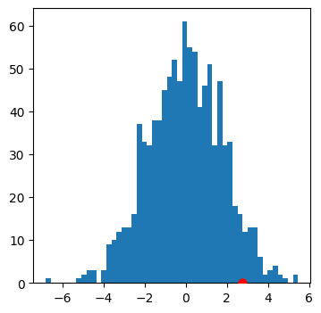

```python
plt.figure(figsize=(4,4))
plt.hist(sales_differences,bins=50)
plt.scatter(test_statistic, 0, color='red', s=40, zorder=3)
```

```python
p_value = 1 - np.count_nonzero(sales_differences <= test_statistic) / repetitions
print(f"p-value is {p_value}")
```

```
p-value is 0.06000000000000005
```

With a significance level of 10%, the obtained p-value is small enough to reject the null hypothesis. Thus, I infer that Promotion 1 is more effective than Promotion 3 in generating higher sales.

#### **A/B Testing Results:**

After conducting A/B testing on the marketing campaign, it's evident that Promotion 1 is the most effective in increasing sales.

##### Chosen Marketing Strategy:

I have decided to implement Promotion 1 for the email marketing campaign.